# KKbox kaggle Data

CY Lan

2017年10月5日

# first step —import data

[output not shown]

# second step —observe data and process

## members.csv檢視及處理

裡面包括了七個欄位如下：

```
## [1] "msno"                   "city"
## [3] "bd"                     "gender"
## [5] "registered_via"         "registration_init_time"
## [7] "expiration_date"
```

檢視一下members各項欄位的分布

```
##                                            msno city bd gender
## 1: URiXrfYPzHAlk+7+n7BOMl9G+T7g8JmrSnT/BU8GmEo=    1  0
## 2: U1q0qCqK/lDMTD2kN8G9OXMtfuvLCey20OAIPOvXXGQ=    1  0
## 3: W6M2H2kAoN9ahfDYKo3J6tmsJRAeuFc9wl1cau5VL1Q=    1  0
## 4: 1qE5+cN7CUyC+KFH6gBZzMWmM1QpIVW6A43BEm98I/w=    5 17 female
## 5: SeAnaZPI+tFdAt+r3lZt/B8PgTp7bcG/1os39u4pLxs=    1  0
## 6: iSJMDbqVrpRf7DRQoCINa6CzxpEIkHj91X5oqpReC3k=    1  0
##    registered_via registration_init_time expiration_date
## 1:              9               20150525        20150526
## 2:              4               20161221        20161224
## 3:              4               20160306        20160309
## 4:              4               20161031        20161107
## 5:              4               20170202        20170205
## 6:              4               20160215        20160218
```

```
##      msno                city             bd               gender
##  Length:5116194     Min.   : 1.00   Min.   :-6998.000   Length:5116194
##  Class :character   1st Qu.: 1.00   1st Qu.:    0.000   Class :character
##  Mode  :character   Median : 1.00   Median :    0.000   Mode  :character
##                     Mean   : 4.02   Mean   :    9.772
##                     3rd Qu.: 5.00   3rd Qu.:   21.000
##                     Max.   :22.00   Max.   : 2015.000
##  registered_via   registration_init_time expiration_date
##  Min.   : 3.000   Min.   :20040326       Min.   :19700101
##  1st Qu.: 4.000   1st Qu.:20141026       1st Qu.:20151107
##  Median : 4.000   Median :20151111       Median :20160705
##  Mean   : 5.248   Mean   :20146314       Mean   :20159812
##  3rd Qu.: 7.000   3rd Qu.:20160607       3rd Qu.:20170610
##  Max.   :16.000   Max.   :20170713       Max.   :21000101
```

接著我們發現裡面包含開始訂的日期、到期日、居住城市、性別、生日以及註冊途徑。 其中有三個類別變數：城市、註冊途徑、性別

而其他連續變數中，年齡看起來有些極端的異常值，負的以及過多的。

性別部分則不是全部都有，因此我們優先處理兩個欄位。

```r
length(members.csv$gender[nchar(members.csv$gender)>0])/nrow(members.csv)
```

```
## [1] 0.3442825
```

透過計算我們可以知道僅有34%的人有性別這欄位

```r
ceiling(table(members.csv$gender)/1761416*100)
```

```
##
##        female   male
##    191     49     52
```

男女比例則是非常接近，男生稍微比女生多

接著對這些進行處理 `members.csv$gender[nchar(members.csv$gender)<1] <- NA` `members.csv$bd[members.csv$bd<0] <- NA` `members.csv$bd[members.csv$bd>100] <- NA` `members.csv$bd[members.csv$bd==0] <- NA`

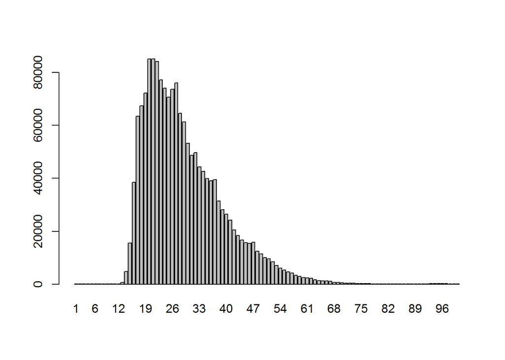

由分布可以看出是個右偏分布（平均數>中位數>眾數）

代表左邊分布較密集，可以看出年齡層偏向年輕人 ##transactions檢視處理

```r
summary(transactions.csv)
```

```
##      msno           payment_method_id payment_plan_days plan_list_price
##  Length:21547746    Min.   : 1.00     Min.   :  0.00    Min.   :   0.0
##  Class :character   1st Qu.:38.00     1st Qu.: 30.00    1st Qu.:  99.0
##  Mode  :character   Median :41.00     Median : 30.00    Median : 149.0
##                     Mean   :38.93     Mean   : 31.34    Mean   : 139.9
##                     3rd Qu.:41.00     3rd Qu.: 30.00    3rd Qu.: 149.0
##                     Max.   :41.00     Max.   :450.00    Max.   :2000.0
##  actual_amount_paid is_auto_renew   transaction_date
##  Min.   :   0       Min.   :0.000   Min.   :20150101
##  1st Qu.:  99       1st Qu.:1.000   1st Qu.:20150906
##  Median : 149       Median :1.000   Median :20160321
##  Mean   : 142       Mean   :0.852   Mean   :20157597
##  3rd Qu.: 149       3rd Qu.:1.000   3rd Qu.:20160925
##  Max.   :2000       Max.   :1.000   Max.   :20170228
##  membership_expire_date   is_cancel
##  Min.   :19700101       Min.   :0.00000
##  1st Qu.:20151019       1st Qu.:0.00000
##  Median :20160430       Median :0.00000
##  Mean   :20158625       Mean   :0.03977
##  3rd Qu.:20161031       3rd Qu.:0.00000
##  Max.   :20170331       Max.   :1.00000
```

# 每個客戶總下過多少訂單

```r
transaction_count<-data.frame(table(transactions.csv$msno))
colnames(transaction_count) <- 'transaction_count'

summary(transaction_count)
```

```
##                                     transaction_count         NA
##  ///2pAPKetZe8zPqAwkYBjAUr+4pS8Rc6bsO4eGAlWI=:      1   Min.   : 1.000
##  ///a8dUVZ8+gM5J3+VFhBTh0KHZLaNv3epSUOaj+B+k=:      1   1st Qu.: 1.000
##  ///daf6jlb8rz6osBGWcYx574YPnoL6hAzohHanZOO0=:      1   Median : 5.000
##  ///L/CeiqRp50C9l0tDfQZVsiEKP2GxtAkyEBw8ojc0=:      1   Mean   : 9.116
##  ///mTKUVQV0oYwb1acUes7piDWa9GLvLDDKru+THzQ0=:      1   3rd Qu.:16.000
##  ///pYJCsKrt3JP6AUO3iEWazTgU0SLLkzfEJM82Efd0=:      1   Max.   :71.000
##  (Other)                                     :2363620
```

# 每個客戶總共取消過多少名單

```r
cancel <- transactions.csv[transactions.csv$is_cancel==1,]
cancel_msno <- data.frame(table(cancel$msno))
colnames(cancel_msno)[2] <- 'cancel_count'
```

# 訂單金額平均

```r
payment_amount <- data.frame(tapply(transactions.csv$actual_amount_paid,transactions.csv$msno,mean))
payment_amount$Var1 <- rownames(payment_amount)
rownames(payment_amount) <- NULL
```

# 合併欄位

```r
load('D:/kaggle/processedDatatrain.RData')
colnames(train)[11] <- 'transaction_dollar'
```

# 敘述統計

開始做各項分析前，我們先說明一下要探測的對象，就是is_churn這個欄位。is_churn代表是否流失，定義是在到期日三十天內未續約，我們就稱他is_churn = 1，反之則是沒有流失。

因此我們首先了解各項變數在客戶流失與否之間的差異，來過濾出較有效的feature。

這邊我們使用is_stay，來取代原本的is_churn。1代表未流失的客戶，0則代表流失。

## ANOVA Analysis

### 年齡

```r
require(ggplot2)
train$color <- NA
train$color[train$is_stay==1] <-'未流失'
train$color[train$is_stay==0] <-'流失'

aov_amount <-aov(bd~is_stay, data=train)
summary(aov_amount)
```

```
##                 Df   Sum Sq Mean Sq F value Pr(>F)
## is_stay          1   215386  215386    2737 <2e-16 ***
## Residuals   394441 31039892      79
## ---
## Signif. codes:  0 '***' 0.001 '**' 0.01 '*' 0.05 '.' 0.1 ' ' 1
## 598488 observations deleted due to missingness
```

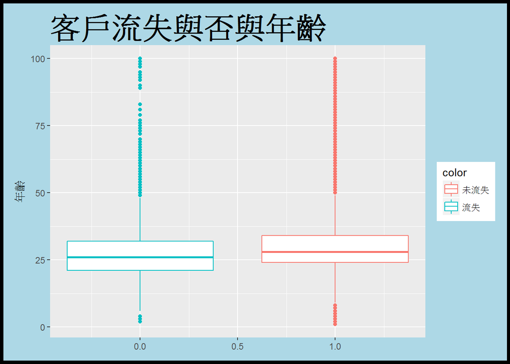

```r
p <- qplot(x=is_stay,
           y=bd,
           data=train,
           geom="boxplot",       # 圖形=boxplot
           xlab=NULL,
           color=color ,
           main = '客戶流失與否與年齡',
           ylab ='年齡'
)
p + theme(plot.background = element_rect(colour = "black", size = 3, linetype = 1,
                                         fill = "lightblue"), plot.title = element_text(colour = "black", face = "bold",
                                                                                        size = 30, vjust = 1), plot.margin = unit(c(0.2, 0.2, 0.2, 0.2), "inches"))
```

### 訂單平均金額

```r
aov_amount <-aov(transaction_dollar~is_stay, data=train)
summary(aov_amount)
```

```
##                 Df    Sum Sq   Mean Sq F value Pr(>F)
## is_stay          1 1.008e+09 1.008e+09   57421 <2e-16 ***
## Residuals   992929 1.743e+10 1.756e+04
## ---
## Signif. codes:  0 '***' 0.001 '**' 0.01 '*' 0.05 '.' 0.1 ' ' 1
```

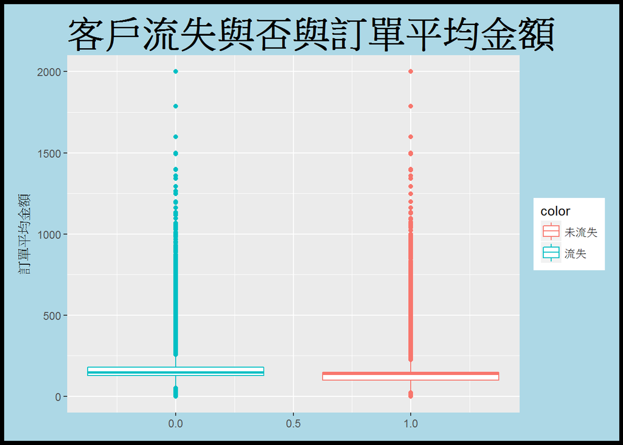

```r
p <- qplot(x=is_stay,
           y=transaction_dollar,
           data=train,
           geom="boxplot",       # 圖形=boxplot
           xlab=NULL,
           color=color ,
           main = '客戶流失與否與訂單平均金額',
           ylab ='訂單平均金額'
)
p + theme(plot.background = element_rect(colour = "black", size = 3, linetype = 1,
                                         fill = "lightblue"), plot.title = element_text(colour = "black", face = "bold", size = 30, vjust = 1), plot.margin = unit(c(0.2, 0.2, 0.2, 0.2), "inches"))
```

## Survival Analysis

### 性別

```r
require(survival)
require(survminer)
```

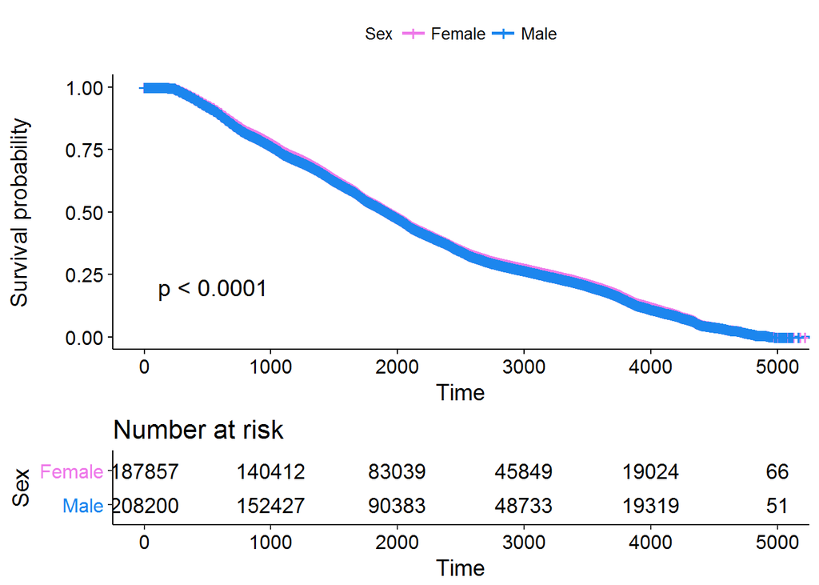

```r
#gender
sfit <- survfit(Surv(suv_time,is_stay)~gender, data=train)
ggsurvplot(sfit, pval=TRUE, risk.table=TRUE,
           legend.labs=c("Female", "Male"), legend.title="Sex",
           palette=c("orchid2","dodgerblue2"),
           main="Kaplan-Meier Curve for KKBOX CUSTOMER Survival",
           risk.table.height=.3)
```

###城市

[figure not shown]

```r
sfit_city <- survfit(Surv(suv_time,is_stay)~city, data=train)


ggsurvplot(sfit_city, pval=TRUE, risk.table=TRUE, legend.title="city",
           main="Kaplan-Meier Curve for KKBOX CUSTOMER Survival",
           risk.table.height=.45)
```

## survival regression

```r
fit <- coxph(Surv(suv_time,is_stay)~city+bd+gender+registered_via+transaction_count+cancel_count+transaction_dollar, data=train)

summary(fit)
```

```
## Call:
## coxph(formula = Surv(suv_time, is_stay) ~ city + bd + gender +
##     registered_via + transaction_count + cancel_count + transaction_dollar,
##     data = train)
##
##   n= 96858, number of events= 85723
##    (896073 observations deleted due to missingness)
##
##                          coef  exp(coef)   se(coef)        z Pr(>|z|)
## city               -0.0075096  0.9925185  0.0006076  -12.360  < 2e-16 ***
## bd                 -0.0218638  0.9783735  0.0005005  -43.686  < 2e-16 ***
## gendermale          0.0018642  1.0018659  0.0068413    0.272    0.785
## registered_via     -0.3164963  0.7286977  0.0017853 -177.282  < 2e-16 ***
## transaction_count  -0.0084808  0.9915551  0.0006110  -13.880  < 2e-16 ***
## cancel_count       -0.0274106  0.9729617  0.0054229   -5.055 4.31e-07 ***
## transaction_dollar -0.0054042  0.9946104  0.0001349  -40.065  < 2e-16 ***
## ---
## Signif. codes:  0 '***' 0.001 '**' 0.01 '*' 0.05 '.' 0.1 ' ' 1
##
##                    exp(coef) exp(-coef) lower .95 upper .95
## city                  0.9925     1.0075    0.9913    0.9937
## bd                    0.9784     1.0221    0.9774    0.9793
## gendermale            1.0019     0.9981    0.9885    1.0154
## registered_via        0.7287     1.3723    0.7262    0.7313
## transaction_count     0.9916     1.0085    0.9904    0.9927
## cancel_count          0.9730     1.0278    0.9627    0.9834
## transaction_dollar    0.9946     1.0054    0.9943    0.9949
##
## Concordance= 0.707  (se = 0.001 )
## Rsquare= 0.308   (max possible= 1 )
## Likelihood ratio test= 35703  on 7 df,   p=0
## Wald test            = 37219  on 7 df,   p=0
## Score (logrank) test = 43414  on 7 df,   p=0
```

```r
print(fit)
```

```
## Call:
## coxph(formula = Surv(suv_time, is_stay) ~ city + bd + gender +
##     registered_via + transaction_count + cancel_count + transaction_dollar,
##     data = train)
##
##                         coef exp(coef)  se(coef)       z       p
## city               -0.007510  0.992519  0.000608  -12.36 < 2e-16
## bd                 -0.021864  0.978373  0.000500  -43.69 < 2e-16
## gendermale          0.001864  1.001866  0.006841    0.27    0.79
## registered_via     -0.316496  0.728698  0.001785 -177.28 < 2e-16
## transaction_count  -0.008481  0.991555  0.000611  -13.88 < 2e-16
## cancel_count       -0.027411  0.972962  0.005423   -5.05 4.3e-07
## transaction_dollar -0.005404  0.994610  0.000135  -40.06 < 2e-16
##
## Likelihood ratio test=35703  on 7 df, p=0
## n= 96858, number of events= 85723
##    (896073 observations deleted due to missingness)
```